# TidyTemplate

2026-01-02

# TidyTuesday

Join the Data Science Learning Community in the weekly #TidyTuesday event! Every week we post a raw dataset, a chart or article related to that dataset, and ask you to explore the data. While the dataset will be “tamed”, it will not always be tidy! As such you might need to apply various R for Data Science techniques to wrangle the data into a true tidy format. The goal of TidyTuesday is to apply your R skills, get feedback, explore other’s work, and connect with the greater #RStats community! As such we encourage everyone of all skills to participate!

```r
library(tidyverse)
library(tidytuesdayR)
library(paletteer)
```

# Load the weekly Data

Download the weekly data and make available in the `tt` object.

```r
tt <- tt_load("2025-12-30")
```

```
## ---- Compiling #TidyTuesday Information for 2025-12-30 ----
## --- There are 3 files available ---
##
##
## ── Downloading files ───────────────────────────────────────────────────────────
##
##   1 of 3: "christmas_novel_authors.csv"
##   2 of 3: "christmas_novel_text.csv"
##   3 of 3: "christmas_novels.csv"
```

```r
colors <- paletteer_c("scico::berlin", n = 15)
```

# Readme

Take a look at the readme for the weekly data to get insight on the dataset. This includes a data dictionary, source, and a link to an article on the data.

```r
tt
```

# Glimpse Data

Take an initial look at the format of the data available.

```r
map(tt, glimpse)
```

```
## Rows: 35
## Columns: 6
## $ gutenberg_author_id <dbl> 37, 266, 313, 362, 102, 1324, 3695, 2334, 2044, 55…
## $ author              <chr> "Dickens, Charles", "Wiggin, Kate Douglas Smith", …
## $ birthdate           <dbl> 1812, 1856, 1811, 1852, 1832, 1863, 1860, 1872, 18…
## $ deathdate           <dbl> 1870, 1923, 1863, 1933, 1888, 1930, 1937, 1956, 19…
## $ wikipedia           <chr> "https://en.wikipedia.org/wiki/Charles_Dickens", "…
## $ aliases             <chr> "Boz/Dickens, Charles John Huffam", "Riggs, Kate D…
## Rows: 114,134
## Columns: 2
## $ gutenberg_id <dbl> 46, 46, 46, 46, 46, 46, 46, 46, 46, 46, 46, 46, 46, 46, 4…
## $ text         <chr> "A CHRISTMAS CAROL", NA, "IN PROSE", "BEING", "A Ghost St…
## Rows: 42
## Columns: 3
## $ gutenberg_id        <dbl> 46, 1902, 2731, 4384, 8694, 10707, 10813, 12881, 1…
## $ title               <chr> "A Christmas Carol in Prose; Being a Ghost Story o…
## $ gutenberg_author_id <dbl> 37, 266, 313, 362, 102, 1324, 3695, 2334, 2044, 55…
```

```
## $christmas_novel_authors
## # A tibble: 35 × 6
##    gutenberg_author_id author              birthdate deathdate wikipedia aliases
##                  <dbl> <chr>                   <dbl>     <dbl> <chr>     <chr>
##  1                  37 Dickens, Charles         1812      1870 https://… Boz/Di…
##  2                 266 Wiggin, Kate Dougl…      1856      1923 https://… Riggs,…
##  3                 313 Thackeray, William…      1811      1863 https://… Titmar…
##  4                 362 Van Dyke, Henry          1852      1933 https://… Dyke, …
##  5                 102 Alcott, Louisa May       1832      1888 https://… Barnar…
##  6                1324 Locke, William John      1863      1930 https://… Locke,…
##  7                3695 Boyd, Mary Stuart        1860      1937 <NA>      <NA>
##  8                2334 Hughes, Rupert           1872      1956 https://… <NA>
##  9                2044 Finley, Martha           1828      1909 https://… Farquh…
## 10                5591 Brady, Cyrus Towns…      1861      1920 https://… <NA>
## # ℹ 25 more rows
##
## $christmas_novel_text
## # A tibble: 114,134 × 2
##    gutenberg_id text
##           <dbl> <chr>
##  1           46 A CHRISTMAS CAROL
##  2           46 <NA>
##  3           46 IN PROSE
##  4           46 BEING
##  5           46 A Ghost Story of Christmas
##  6           46 <NA>
##  7           46 by Charles Dickens
##  8           46 <NA>
##  9           46 <NA>
## 10           46 <NA>
## # ℹ 114,124 more rows
##
## $christmas_novels
## # A tibble: 42 × 3
##    gutenberg_id title                                        gutenberg_author_id
##           <dbl> <chr>                                                      <dbl>
##  1           46 A Christmas Carol in Prose; Being a Ghost S…                  37
##  2         1902 The Old Peabody Pew: A Christmas Romance of…                 266
##  3         2731 The Christmas Books of Mr. M.A. Titmarsh                     313
##  4         4384 The Lost Word: A Christmas Legend of Long A…                 362
##  5         8694 The Abbot's Ghost, or Maurice Treherne's Te…                 102
##  6        10707 A Christmas Mystery: The Story of Three Wis…                1324
##  7        10813 A Versailles Christmas-Tide                                 3695
##  8        12881 Mrs. Budlong's Christmas Presents                           2334
##  9        14534 Christmas with Grandma Elsie                                2044
## 10        14606 And Thus He Came: A Christmas Fantasy                       5591
## # ℹ 32 more rows
```

# Wrangle

Explore the data and process it into a nice format for plotting! Access each dataset by name by using a dollarsign after the `tt` object and then the name of the data set.

```r
christmas_novel_authors <- tt$christmas_novel_authors
christmas_novel_text <- tt$christmas_novel_text
christmas_novels <- tt$christmas_novels

process_data <- christmas_novel_authors |>
        full_join(
                christmas_novels,
                by=join_by(gutenberg_author_id)
        ) |>
        full_join(
                christmas_novel_text,
                by=join_by(gutenberg_id),
                relationship = "many-to-many"
        ) |>
        filter(!is.na(text))
```

```r
clean_words <- process_data |>
  select(title,text,birthdate) |>
  mutate(text=tolower(text),
         text=gsub("\\.|\\:|\\,|\\'s|\\?|\\!|\\;| |\\--|\"|\'"," ",text)
         )

raw_words <- clean_words |>
  filter(birthdate>1860) |>
  pull(text) |>
  str_split(" ") |>
  unlist() |>
  table() |>
  as.data.frame() |>
  filter(Var1!="") |>
  full_join(
    clean_words |>
  filter(birthdate<1825) |>
  pull(text) |>
  str_split(" ") |>
  unlist() |>
  table() |>
  as.data.frame() |>
  filter(Var1!="") |>
  rename(oldies=Freq),
  by=join_by(Var1)
  ) |> mutate(diff=oldies-Freq)
```

# Visualize

Using your processed dataset, create your unique visualization.

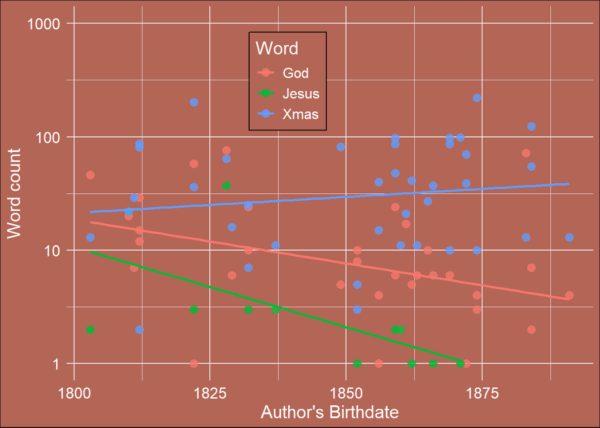

```r
process_data |>
        mutate(God=grepl("God",text),
               Jesus=grepl("Jesus",text),
               Xmas=grepl("Christmas|christmas|xmas|xmases",text),
               angel=grepl("Angel|angel",text)) |>
        pivot_longer(cols = c("God","Jesus","Xmas"), names_to = "Word") |>
        filter(value) |>
        group_by(title,birthdate, Word) |>
        summarise(n=n()) |>
        ggplot(
                aes(
                        x=birthdate,
                        y=n,
                        col=Word
                )
        )+
        geom_point(size=3,alpha=0.8)+
        stat_smooth(se = F, method="lm")+
        theme_minimal()+
  scale_y_log10(limits=c(1,1000))+
  xlab("Author's Birthdate")+ylab("Word count")+
  theme(legend.position="inside",
        legend.position.inside = c(0.42,0.8),
        legend.background = element_rect(colour = "black",fill=colors[13]),
        plot.background = element_rect(fill=colors[13]),
        text = element_text(color = "white",size=15),
        axis.text = element_text(color = "white",size=13))
```

# Save Image

Save your image for sharing. Be sure to use the `#TidyTuesday` hashtag in your post on twitter!

```r
# This will save your most recent plot
ggsave(
  filename = paste("My TidyTuesday Plot_",Sys.Date(),".png",sep = ""),
  device = "png"
)
```